# prad-signature

## prad-signature

*Last modified 09:46 PM on Apr 09, 2015. This document, R session image, knitr cache, figures, and other associated datasets are located in `cruncher:/inside/grotto/blin/trna-markers/prad/prad-signature/`.*

```r
library(DESeq2)
library(BiocParallel)
register(MulticoreParam(10))
library(stringr)
library(ROCR)
library(dplyr)
load('/inside/grotto/blin/trna-markers/feature-counts/features.RData')
load('/inside/grotto/blin/trna-markers/feature-counts/feature-counts.RData')
```

```
## Error: error reading from connection
```

```r
load('/inside/grotto/blin/trna-markers/batch-effects/counts.RData')
```

First things first, let's remove NA values (which happens when there is no corresponding RNA-Seq count data for housekeeping genes) and duplicated tsRNA/miRNA rows. Duplicates arise from different loci transcribing the same gene. We want to keep only 1 locus.

DESeq2 estimates gene dispersions in a 3 step process. First, it considers individual genes, and looks at their dispersions across all samples. Second, it fits a curve to the individual gene dispersions. Third, it uses the curve as a prior to shrink the individual dispersions towards the curve. Thus, duplicated genes will affect the fitted curve, and subsequently the dispersion adjustments towards the prior.

```r
na_indices <- sapply(feature_counts, function(col) any(is.na(col)))
tRFs <- features[features$class %in% c("tRF1", "tRF3", "tRF5")]$tx_name
miRNAs <- features[features$class == "miRNA"]$tx_name
duplicated_indices <- duplicated(str_match(unlist(str_split(tRFs, "\\-", 2))[seq(2, length(tRFs)*2, 2)], "\\w+-\\d+")[, 1])
duplicated_indices <- c(duplicated_indices, duplicated(miRNAs))
feature_counts <- feature_counts[!duplicated_indices, !na_indices] # 10 mRNA genes unspecified, but R keeps them in unless explicitly told to remove them
prad_metadata <- prad_metadata[-na_indices, ]
```

We want to make both miRNA and tsRNA signatures, and use them to predict cancer status (normal vs tumor). First, we want to perform differential expression, tumor versus normal. So we need to split into training/testing sets. This split needs to have an appropriate number of normal and tumor samples.

```r
randomSamplePatients <- function(metadata) {
    # sample pairs of samples first
    paired_metadata <- metadata[metadata$paired, ]
    paired_samples <- sample(as.factor(paired_metadata$participant_id), nrow(paired_metadata)/2)
    # then sample single sample patients
    unpaired_metadata <- metadata[!metadata$paired, ]
    unpaired_samples <- sample(as.factor(unpaired_metadata$participant_id), nrow(unpaired_metadata)/2)
    # combine patient ids
    c(as.character(paired_samples), as.character(unpaired_samples))
}
random_sample <- randomSamplePatients(prad_metadata)
training_counts <- feature_counts[, prad_metadata$participant_id %in% random_sample]
training_metadata <- prad_metadata[prad_metadata$participant_id %in% random_sample, ]
testing_counts <- feature_counts[, !(prad_metadata$participant_id %in% random_sample)]
testing_metadata <- prad_metadata[!(prad_metadata$participant_id %in% random_sample), ]
```

```r
runDESeq2 <- function(counts, metadata) {
  colData <- data.frame(row.names = colnames(counts), patient = as.factor(metadata$participant_id), sample_type = metadata$sample_type, type = "single-read")
    # feature count column names correspond to metadata rows
  controls <- (nrow(counts) - 9):nrow(counts) # last 10 genes for PRAD are controls
  dds <- DESeqDataSetFromMatrix(countData = counts, colData = colData, design = ~ patient + sample_type)
  dds <- estimateSizeFactors(dds, controlGenes = controls)
  dds <- estimateDispersions(dds)
  dds <- nbinomWaldTest(dds)
  results(dds)
}
```

```r
deseq_res <- runDESeq2(training_counts, training_metadata)
head(deseq_res[order(deseq_res$padj), c(1,2,4,5)])
```

```
## log2 fold change (MAP): sample_type TP vs NT
## Wald test p-value: sample_type TP vs NT
## DataFrame with 6 rows and 4 columns
##                             baseMean log2FoldChange      stat       pvalue
##                            <numeric>      <numeric> <numeric>    <numeric>
## chr5.trna6-ValCAC-3008a   152.139505     -1.4256442 -7.537978 4.773156e-14
## chr15.trna2-LysCTT-5006c   87.900181     -1.1828066 -6.319275 2.627930e-10
## chr16.trna10-LysCTT-5005a  88.578963     -1.1425636 -6.190891 5.982520e-10
## chr12.trna4-AspGTC-5032a  144.386917     -0.9761638 -6.013292 1.817928e-09
## chr16.trna17-LeuCAG-3012a   5.311687     -1.3547676 -5.794286 6.861227e-09
## chr1.trna52-ProCGG-5012a   37.745075     -0.8774295 -5.714586 1.099712e-08
```

```r
length(which(deseq_res$padj < 0.05 & abs(deseq_res$log2FoldChange) > 1))
```

```
## [1] 10
```

I need to do supervised PCA or LDA something, but i'm just gonna figure out LM first and see if that works lool.

```r
top_tRFs <- deseq_res[rownames(deseq_res) %in% tRFs, ]
top_tRFs <- top_tRFs[order(top_tRFs$padj), ]
top_tRFs <- rownames(top_tRFs[which(top_tRFs$padj < 0.05 & abs(top_tRFs$log2FoldChange) > 1), ])[1:9]
top_miRNAs <- deseq_res[rownames(deseq_res) %in% miRNAs, ]
top_miRNAs <- top_miRNAs[order(top_miRNAs$padj), ]
top_miRNAs <- rownames(top_miRNAs)[1:9]
```

```r
x <- data.frame(sample_type = as.factor(training_metadata$sample_type), t(training_counts[top_tRFs, ]))
tRF_glm <- glm(as.formula(paste("sample_type ~ ", paste0(make.names(top_tRFs), collapse = ' + '))), data = x, family = "binomial") # binomial family specifies logistic regression, for NT vs TP
x <- data.frame(sample_type = as.factor(training_metadata$sample_type), t(training_counts[top_miRNAs, ]))
miRNA_glm <- glm(as.formula(paste("sample_type ~ ", paste0(make.names(top_miRNAs), collapse = ' + '))), data = x, family = "binomial")
```

```r
testing_counts_tRFs <- as.data.frame(t(testing_counts[top_tRFs, ]))
colnames(testing_counts_tRFs) <- make.names(top_tRFs)
predicted <- predict(tRF_glm, newdata = testing_counts_tRFs, se.fit = TRUE)
prob <- prediction(predicted$fit, testing_metadata$sample_type)
performance <- performance(prob, "tpr", "fpr")
roc <- data.frame(TPR = unlist(performance@y.values), FPR = unlist(performance@x.values), Signature = "tRF")
tRF_auc <- performance(prob, "auc")
tRF_auc <- unlist(tRF_auc@y.values)

testing_counts_miRNAs <- as.data.frame(t(testing_counts[top_miRNAs, ]))
colnames(testing_counts_miRNAs) <- make.names(top_miRNAs)
predicted <- predict(miRNA_glm, newdata = testing_counts_miRNAs, type = "response", se.fit = TRUE)
prob <- prediction(predicted$fit, testing_metadata$sample_type)
performance <- performance(prob, "tpr", "fpr")
roc <- rbind(roc, data.frame(TPR = unlist(performance@y.values), FPR = unlist(performance@x.values), Signature = "miRNA"))
miRNA_auc <- performance(prob, "auc")
miRNA_auc <- unlist(miRNA_auc@y.values)

plot <- ggplot(roc) + geom_line(aes(x = FPR, y = TPR, color = Signature)) + geom_abline(intercept = 0, slope = 1, colour = "gray") + ylab("TPR") + xlab("FPR") + scale_color_discrete(name = "Signature", labels = c(paste0("tRF (AUC = ", round(tRF_auc, 3), ")"), paste0("miRNA (AUC = ", round(miRNA_auc, 3), ")"))) + theme_bw()
```

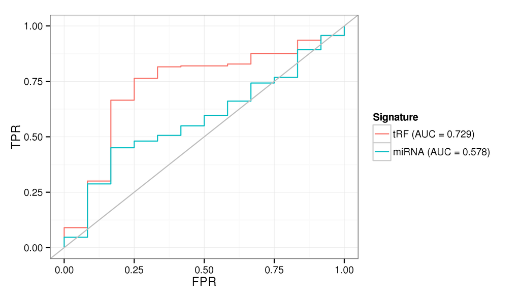

```r
plot
```

```r
save.image("prad-signature-image.RData")
```